# Lecture example

## Anderson M Amaral (amamaral.github.io)

### Jupyter Notebook's slides, MathJax and reveal.js

## Equations and transitions

- The current Jupyter notebook has been adapted for lectures using math
- Contents can appear
- Or fade up, down, left or right.
- They can even be highlighted in red, blue or green

Equations can be written as $\LaTeX$ and interpreted by MathJax. \begin{equation} \int_0^\infty x dx = \left.\frac{x^2}{2}\right|_{x=0}^\infty + C_1 \end{equation}

And also highlighted $$ \int_0^\infty x dx = \left.\frac{x^2}{2}\right|_{x=0}^\infty + C_2 $$

- Equations can also be displayed sequentially:
  - $x + $$42 = $$68$
  - $x = $$68 $$-42$
  - $x=26$

```python
# Jupyter code cell
68-42
```

```
26
```

## Code execution

- The slides can execute python scripts during slides compilation.
- By default, the input is hidden and output is shown.
- The button reveals the relevant Jupyter input code

```python
(2+2*2)/2-2
```

```
1.0
```

- If the code becomes too long, a scrollbar will appear

```python
"""
Here there is a very long code,

because there are lots of comments,

spanning several lines.

There is so much info for a single slide!
"""

def verbose(string):
    a = ''
    for s in string:
        a += (s + s + s + s)
    return a

print(verbose('ouch!'))
```

```
oooouuuucccchhhh!!!!
```

## Matplotlib integration

- It becomes easy to use matplotlib to produce slides
- Using `%pylab inline` magic for simpler notation (see Jupyter notebook's first cell)

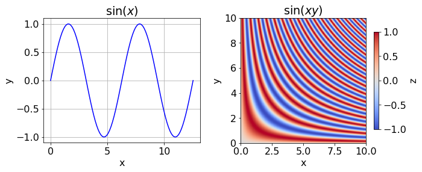

```python
# Left figure

subplot(121, aspect=5)

x = linspace(0,4*pi, 100)
y = sin(x)

grid()
title(r'$\sin(x)$')
xlabel('x')
ylabel('y')
plot(x,y, color='blue')

# Right figure
subplot(122, aspect=1.0)

x = linspace(0,10, 500)
y = linspace(0,10, 500)

xx, yy = meshgrid(x,y)

title(r'$\sin(x y)$')
xlabel('x')
ylabel('y')
im = pcolormesh(xx, yy, sin(xx*yy), cmap=cm.coolwarm, vmin=-1.0, vmax=1.0)
cb = colorbar(im, shrink=0.3)
cb.set_ticks([-1.0, -0.5, 0, 0.5, 1.0])
cb.set_label('z')

tight_layout()
```

## Usage

- Create a Jupyter Notebook (`example.ipynb`) in a given folder (e.g.: `slides/`)
- Within `slides/`, add reveal.js
  - `git clone https://github.com/hakimel/reveal.js.git`, or
  - download and unzip [reveal.js](https://github.com/hakimel/reveal.js/).
- Copy `slides_template.tpl` and `basic_mod.tpl` to `slides/`
- Run `jupyter nbconvert --to slides --template slides_template.tpl example.ipynb --reveal-prefix=reveal.js`
  - `--reveal-prefix={folder}` indicates where reveal.js folder is located